# Biostatistics - Bioinformatics for Computational Genomics

Final Examination Template

Professor: Francesca Ieva | Teaching Assistant: Stefania Colombo

Academic Year 2025/2026

# Student Information

| Field | Information |
| --- | --- |
| **Name** | Giacomo |
| **Surname** | Pogliana |
| **Student ID (Matricola)** | 308411 |
| **Personal Code** | 11182334 |

# Instructions

- Answer **only the two assigned questions**
- Clearly justify all methodological choices
- Report relevant statistical results
- Provide biological and clinical interpretation of findings
- Include comments directly below each code chunk

# Initial Setup

## 1. Load Required Libraries

```r
library(survival)
library(survminer)
library(ggplot2)
library(lme4)
library(lmerTest)
library(insight)
```

## 2. Load the Dataset

```r
load("autoimmune_study.RData")

patients <- final_data$patients
genotypes <- final_data$genotypes
snp_info <- final_data$snp_info
biomarker_data <- final_data$biomarker_data
```

## 3. Preliminary Data Inspection

```r
str(patients)
```

```
## tibble [1,000 × 12] (S3: tbl_df/tbl/data.frame)
##  $ patient_id            : int [1:1000] 1 2 3 4 5 6 7 8 9 10 ...
##  $ sex                   : chr [1:1000] "male" "female" "male" "male" ...
##  $ age                   : num [1:1000] 44 57 22 46 59 54 41 57 39 53 ...
##  $ inflammatory_index    : num [1:1000] 6.4 8 6.4 3.6 2.6 4.1 6.2 4.3 4.6 7.1 ...
##  $ steroid_use           : int [1:1000] 1 0 0 1 1 1 0 0 0 0 ...
##  $ prior_relapse         : int [1:1000] 0 1 1 0 0 0 1 0 0 1 ...
##  $ treatment_arm         : chr [1:1000] "standard" "biologic" "standard" "standard" ...
##  $ center                : chr [1:1000] "Center_A" "Center_C" "Center_C" "Center_A" ...
##  $ time_to_flare         : num [1:1000] 8.593 0.792 2.901 1.782 1.358 ...
##  $ time_to_complication  : num [1:1000] 9.68 4.77 12.71 6.54 4.7 ...
##  $ time_to_severe_outcome: num [1:1000] 10 7.37 10 7.51 5.83 ...
##  $ outcome_type          : chr [1:1000] "censored" "hospitalization" "censored" "hospitalization" ...
```

```r
str(genotypes)
```

```
## 'data.frame':    1000 obs. of  736 variables:
##  $ locus_1_snp_1  : int  2 0 0 2 1 0 1 1 0 1 ...
##  $ locus_1_snp_2  : int  2 1 0 1 0 0 0 1 1 2 ...
##  $ locus_1_snp_3  : int  0 0 0 1 0 0 0 0 0 0 ...
##  $ locus_1_snp_4  : int  0 1 1 0 0 0 0 0 0 0 ...
##  $ locus_1_snp_5  : int  0 0 0 2 0 0 0 0 0 0 ...
##  $ locus_1_snp_6  : int  1 1 0 0 0 0 0 0 1 0 ...
##  $ locus_1_snp_7  : int  0 0 2 1 1 0 1 0 1 0 ...
##  $ locus_1_snp_8  : int  0 0 1 1 1 2 0 0 0 0 ...
##  $ locus_1_snp_9  : int  0 0 1 0 2 1 0 0 0 1 ...
##  $ locus_1_snp_10 : int  2 0 1 1 0 0 0 1 0 0 ...
##  $ locus_1_snp_11 : int  0 0 0 1 0 0 1 1 1 0 ...
##  $ locus_1_snp_12 : int  0 1 2 2 1 1 0 0 1 2 ...
##  $ locus_1_snp_13 : int  0 0 1 1 1 1 2 0 1 1 ...
##  $ locus_1_snp_14 : int  0 0 0 0 0 0 0 0 0 0 ...
```

[output cut: 86 more lines]

```r
str(snp_info)
```

```
## 'data.frame':    735 obs. of  4 variables:
##  $ locus     : chr  "locus_1" "locus_1" "locus_1" "locus_1" ...
##  $ locus_type: chr  "metabolic" "metabolic" "metabolic" "metabolic" ...
##  $ snp_id    : chr  "locus_1_snp_1" "locus_1_snp_2" "locus_1_snp_3" "locus_1_snp_4" ...
##  $ effect    : chr  "flare" "flare" "flare" "flare" ...
```

```r
str(biomarker_data)
```

```
## tibble [54,708 × 4] (S3: tbl_df/tbl/data.frame)
##  $ patient_id: int [1:54708] 1 1 1 1 1 1 1 1 1 1 ...
##  $ time      : num [1:54708] 2.95 2.95 2.95 2.95 2.95 ...
##  $ biomarker : chr [1:54708] "cytokine_1" "cytokine_2" "cytokine_3" "cytokine_4" ...
##  $ value     : num [1:54708] 12.32 5.26 4.91 8.95 8.49 ...
```

# Question 1

## Question 13

> Fit and compare linear mixed effects models for cytokine levels in individual patients:
> 1. Fit a model with:
>    - time, age, sex, treatment arm, and inflammatory index as fixed effects
>    - a random intercept for for patient. Interpret the results and verify the assumptions.
> 2. Extend the model by adding a random slope for time at patient level.
> 3. Compare the two models and assess whether allowing patient-specific trajectories improves the model fit. Clearly justify your choice.
> 4. For the selected model plot estimated individual cytokine trajectories.

## Step 1

```r
# Merge cytokine measurements with patient-level covariates
cyto_lev <- merge(biomarker_data,
                  patients[, c("patient_id", "age", "sex",
                               "treatment_arm", "inflammatory_index")],
                  by = "patient_id")

# Fit M1: fixed effects for time, age, sex, treatment arm and inflammatory
# index; random intercept for patient_id
cyto_lev_mod_1 = lmer(value ~ time + age + sex + treatment_arm + inflammatory_index + (1 | patient_id), data=cyto_lev)

summary(cyto_lev_mod_1)
```

```
## Linear mixed model fit by REML. t-tests use Satterthwaite's method [
## lmerModLmerTest]
## Formula: value ~ time + age + sex + treatment_arm + inflammatory_index +
##     (1 | patient_id)
##    Data: cyto_lev
##
## REML criterion at convergence: 219745.2
##
## Scaled residuals:
##     Min      1Q  Median      3Q     Max
## -4.5828 -0.6730  0.0090  0.6724  5.1478
##
## Random effects:
##  Groups     Name        Variance  Std.Dev.
##  patient_id (Intercept) 0.0007816 0.02796
##  Residual               4.0113424 2.00283
## Number of obs: 51973, groups:  patient_id, 1000
##
## Fixed effects:
##                         Estimate Std. Error         df t value Pr(>|t|)
## (Intercept)            8.193e+00  5.178e-02  1.167e+03 158.214   <2e-16 ***
## time                   1.450e-01  3.409e-03  4.796e+03  42.531   <2e-16 ***
## age                    3.345e-04  6.868e-04  9.633e+02   0.487    0.626
## sexmale               -5.643e-03  1.779e-02  9.325e+02  -0.317    0.751
## treatment_armstandard -1.373e-02  1.770e-02  9.361e+02  -0.776    0.438
## inflammatory_index     4.249e-03  4.975e-03  9.377e+02   0.854    0.393
## ---
## Signif. codes:  0 '***' 0.001 '**' 0.01 '*' 0.05 '.' 0.1 ' ' 1
##
## Correlation of Fixed Effects:
##             (Intr) time   age    sexmal trtmn_
## time        -0.411
## age         -0.778  0.159
## sexmale     -0.207 -0.002  0.063
## trtmnt_rmst -0.190  0.056  0.005  0.014
## inflmmtry_n -0.548  0.120  0.072 -0.052 -0.008
```

```r
# PVRE: proportion of variance explained by the random intercept
sigma2_eps <- as.numeric(get_variance_residual(cyto_lev_mod_1))
sigma2_b   <- as.numeric(get_variance_random(cyto_lev_mod_1))
PVRE       <- sigma2_b / (sigma2_b + sigma2_eps)
PVRE
```

```
## [1] 0.0001948199
```

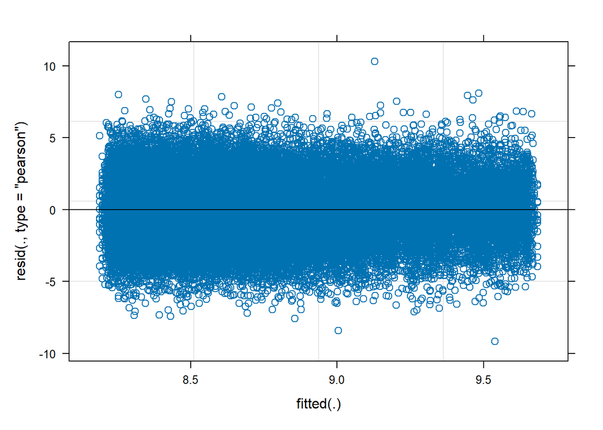

```r
# Residuals vs fitted
plot(cyto_lev_mod_1)
```

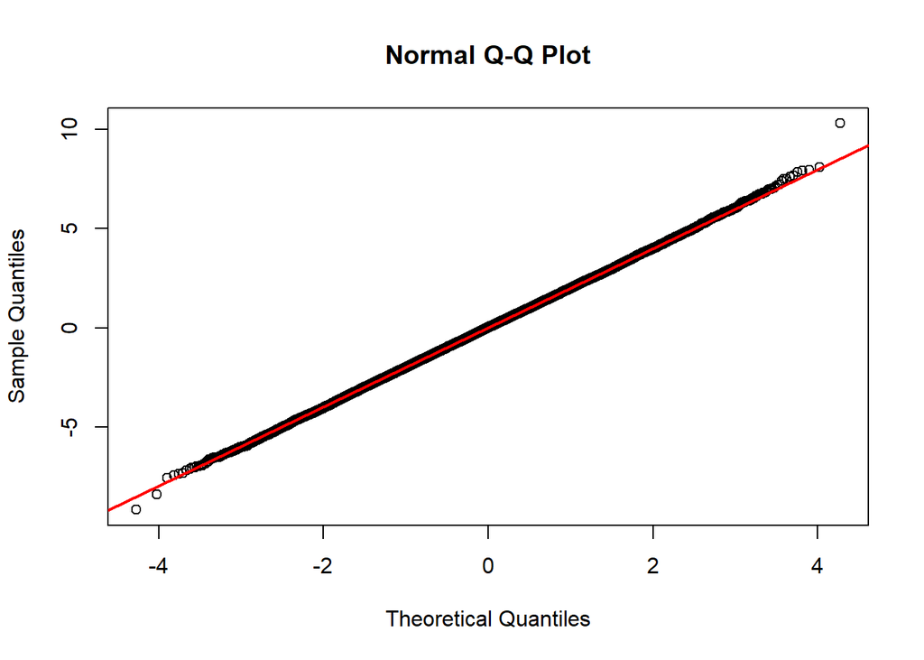

```r
# Q-Q plot of residuals
qqnorm(resid(cyto_lev_mod_1))
qqline(resid(cyto_lev_mod_1), col='red', lwd=2)
```

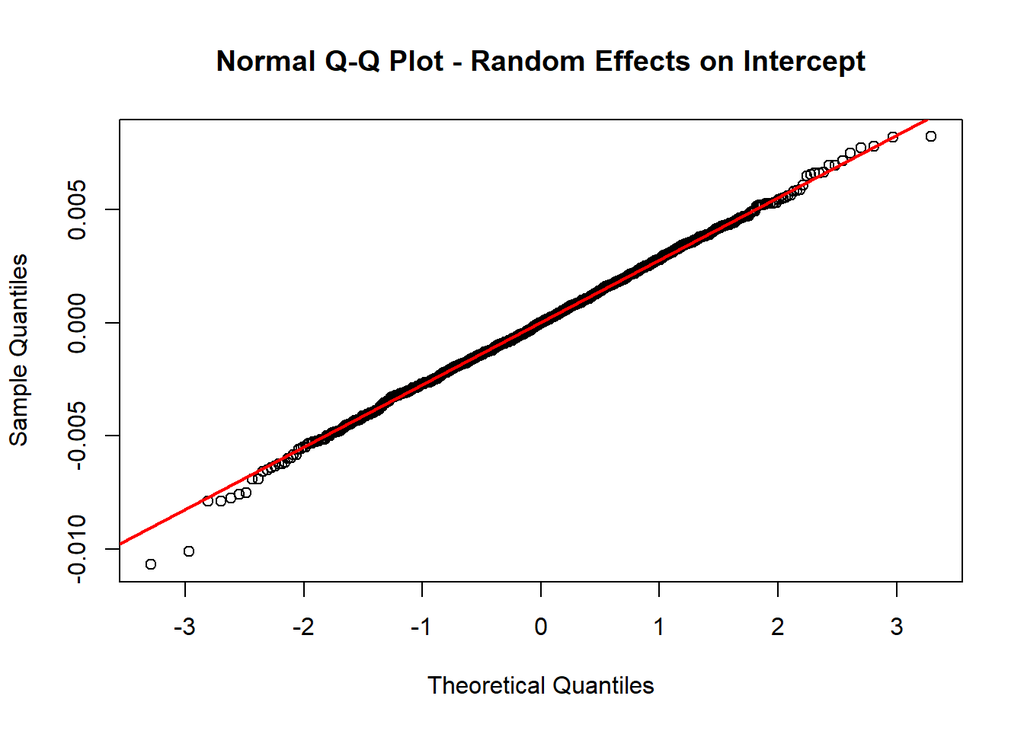

```r
# Q-Q plot of random intercept
qqnorm(unlist(ranef(cyto_lev_mod_1)$patient_id), main='Normal Q-Q Plot - Random Effects on Intercept')
qqline(unlist(ranef(cyto_lev_mod_1)$patient_id), col='red', lwd=2)
```

### Interpretation

The dataset contains longitudinal measurements of 12 cytokines per patient at multiple time points, stored in long format in ‘biomarker_data’. Rather than aggregating the cytokine measurements into a single summary score, all individual observations are retained as the response variable ‘value’, preserving the biological heterogeneity across cytokines. The random intercept for ‘patient_id’ accounts for the non-independence of repeated observations from the same patient.

Time is the only statistically significant predictor ($\hat\beta_1 = 0.145$, p < 0.05): for each unit increase in time, cytokine levels increase by 0.145 units on average, holding all other covariates fixed. None of the remaining predictors reach statistical significance (p > 0.05). The PVRE is 0.02%, indicating that only a very small fraction of the total variability in cytokine levels is attributable to differences between patients.

As shown in the plots, the model assumptions are satisfied: the residuals-versus-fitted plot shows a random scatter around zero, supporting homoscedasticity of residuals, the Q-Q plot of residuals shows points closely aligned with the reference line, supporting normality of residuals and the Q-Q plot of the random intercepts shows points aligning with the reference line, supporting normality of random effects.

Biologically, the significant positive effect of time indicates a progressive increase in cytokine levels over the observation period. The absence of significant effects for treatment arm, age, sex, and inflammatory index suggests that these variables do not independently predict cytokine dynamics after accounting for the temporal trend.

## Step 2

```r
# Fit M2: extends M1 by adding a random slope for time at patient level
cyto_lev_mod_2 = lmer(value ~ time + age + sex + treatment_arm + inflammatory_index + (1+time| patient_id), data=cyto_lev)

summary(cyto_lev_mod_2)
```

```
## Linear mixed model fit by REML. t-tests use Satterthwaite's method [
## lmerModLmerTest]
## Formula: value ~ time + age + sex + treatment_arm + inflammatory_index +
##     (1 + time | patient_id)
##    Data: cyto_lev
##
## REML criterion at convergence: 219745.2
##
## Scaled residuals:
##     Min      1Q  Median      3Q     Max
## -4.5833 -0.6731  0.0090  0.6726  5.1481
##
## Random effects:
##  Groups     Name        Variance  Std.Dev. Corr
##  patient_id (Intercept) 1.793e-03 0.042344
##             time        1.013e-05 0.003183 -1.00
##  Residual               4.011e+00 2.002771
## Number of obs: 51973, groups:  patient_id, 1000
##
## Fixed effects:
##                         Estimate Std. Error         df t value Pr(>|t|)
## (Intercept)            8.193e+00  5.186e-02  1.282e+03 157.989   <2e-16 ***
## time                   1.450e-01  3.410e-03  7.231e+03  42.526   <2e-16 ***
## age                    3.349e-04  6.878e-04  1.076e+03   0.487    0.626
## sexmale               -5.678e-03  1.782e-02  1.053e+03  -0.319    0.750
## treatment_armstandard -1.369e-02  1.772e-02  1.069e+03  -0.772    0.440
## inflammatory_index     4.234e-03  4.982e-03  1.059e+03   0.850    0.396
## ---
## Signif. codes:  0 '***' 0.001 '**' 0.01 '*' 0.05 '.' 0.1 ' ' 1
##
## Correlation of Fixed Effects:
##             (Intr) time   age    sexmal trtmn_
## time        -0.412
## age         -0.778  0.159
## sexmale     -0.207 -0.002  0.063
## trtmnt_rmst -0.189  0.055  0.004  0.014
## inflmmtry_n -0.548  0.120  0.072 -0.052 -0.008
## optimizer (nloptwrap) convergence code: 0 (OK)
## boundary (singular) fit: see help('isSingular')
```

### Interpretation

The model cyto_lev_mod_2 extends cyto_lev_mod_1 by adding a patient-specific random slope for time, allowing each patient to have their own rate of change in cytokine levels over time in addition to their own baseline level. The fixed effect estimates are virtually identical to those of cyto_lev_mod_1($\hat\beta_1 = 0.145$, p < 0.05), confirming that the population-average trajectory is stable across model specifications. However, cyto_lev_mod_2 produces a singular fit (warning: boundary (singular) fit): the random slope variance is practically zero (random slope variance = 1.013e-5), indicating that the data do not support patient-specific temporal trajectories. All patients share essentially the same rate of change in cytokine levels over time, and allowing the slope to vary by patient does not add meaningful information to the model.

From a biological perspective, this suggests that the rate of cytokine increase over time is uniform across patients, regardless of their individual characteristics.

## Step 3

```r
#LRT
anova(cyto_lev_mod_1, cyto_lev_mod_2)
```

|  | npar | AIC | BIC | logLik | -2*log(L) | Chisq | Df | Pr(>Chisq) |
| --- | --- | --- | --- | --- | --- | --- | --- | --- |
| cyto_lev_mod_1 | 8 | 219710.1 | 219781.0 | -109847 | 219694.1 | NA | NA | NA |
| cyto_lev_mod_2 | 10 | 219714.1 | 219802.6 | -109847 | 219694.1 | 0.03087807 | 2 | 0.9846795 |

### Interpretation

The two models are compared using a Likelihood Ratio Test (LRT). The anova function automatically refits both models with ML instead of REML to allow a valid comparison of models with different random effects structures.

The p-value for the test is very high, 0.985, so we prefer cyto_lev_mod_1. This result is consistent with the singular fit observed in M2, where the random slope variance was practically zero, confirming that allowing patient-specific temporal trajectories does not improve the model.

cyto_lev_mod_1 is therefore selected as the final model.

## Step 4

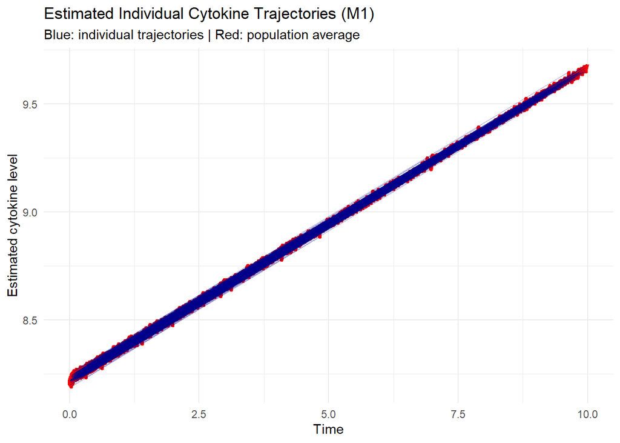

```r
# Extract dataset
cyto_lev_clean <- model.frame(cyto_lev_mod_1)

# Add predicted values
cyto_lev_clean$fitted     <- predict(cyto_lev_mod_1)
cyto_lev_clean$fitted_pop <- predict(cyto_lev_mod_1, re.form = NA)

# Plot
ggplot(cyto_lev_clean, aes(x = time)) +
  geom_line(aes(y = fitted_pop),
            color = "red", linewidth = 1.5) +
  geom_line(aes(y = fitted, group = patient_id),
            alpha = 0.4, color = "darkblue", linewidth = 0.3) +
  labs(
    title    = "Estimated Individual Cytokine Trajectories (M1)",
    subtitle = "Blue: individual trajectories | Red: population average",
    x        = "Time",
    y        = "Estimated cytokine level"
  ) +
  theme_minimal()
```

### Interpretation

The plot shows the estimated individual cytokine trajectories (blue) for all 1,000 patients alongside the population average trajectory (red), as predicted by cyto_lev_mod_1. All individual trajectories cluster tightly around the population average, which is consistent with the very low PVRE (0.02%): patient-specific baseline differences are very small and all patients share the same rate of increase in cytokine levels over time. The positive slope of the population average confirms the significant effect of time found in cyto_lev_mod_1.

## Final Comment for Question 1

cyto_lev_mod_1, with fixed effects for time, age, sex, treatment arm and inflammatory index and a random intercept for patient, was selected as the final model. Time was the only significant predictor, indicating a progressive increase in cytokine levels over the observation period. The very low PVRE (0.02%) suggests that between-patient differences in baseline cytokine levels are very small, and the LRT confirmed that adding patient-specific temporal trajectories (cyto_lev_mod_2) does not improve the model fit. The estimated individual trajectories are consistent with these findings.

# Question 2

## Question 14

> Study the association between genetic variants in `locus_5` and time to severe clinical outcome.
> 1. For each SNP in `locus_5`, convert genotype dosage into three (0,1,2).
> 2. Define time to severe outcome as the endpoint of interest, where event is defined as hospitalization (exclude treatment failure).
> 3. For each SNP, estimate Kaplan-Meir curves stratified by genotype and visually compare survival patterns across groups.
> 4. Assess statistically whether time to severe outcome differs across genotype groups using an appropriate test. Report and interpret the results.
> 5. For one representative SNP:
>    - report median time to severe outcome by genotype group
>    - report survival probabilities at 2, 5, 10 years.

## Step 1

```r
#SNP IDs from locus_5
snps_locus5 <- snp_info$snp_id[snp_info$locus == "locus_5"]

geno_l5 <- genotypes[, c("patient_id", snps_locus5)]

#Convert genotype dosage to categorical factor
for (snp in snps_locus5) {
  geno_l5[[snp]] <- factor(geno_l5[[snp]], levels = c(0, 1, 2))
}
```

### Interpretation

For each SNP in locus_5, genotype dosage values were already stored as integers (0, 1, 2) in the dataset. They were converted to categorical factors with three levels: 0 (homozygous reference), 1 (heterozygous), and 2 (homozygous alternative allele), to allow stratification of survival curves by genotype group.

## Step 2

```r
# Define event indicator: 1 = hospitalization, 0 = otherwise
patients$status_hosp <- ifelse(patients$outcome_type == "hospitalization", 1, 0)

# Merge clinical data with genotype data
data_locus5 <- merge(patients, geno_l5, by = "patient_id")
```

### Interpretation

The endpoint of interest is time to severe clinical outcome, defined as hospitalization. The event indicator was set to 1 for patients whose outcome was hospitalization, and 0 for all others. Treatment failure was treated as censoring, meaning these patients are included in the analysis but assumed not to have experienced the event of interest at their observed time. The clinical and genotype datasets were then merged by patient ID, resulting in a dataset of 1000 patients with 42 SNPs from locus_5.

## Step 3

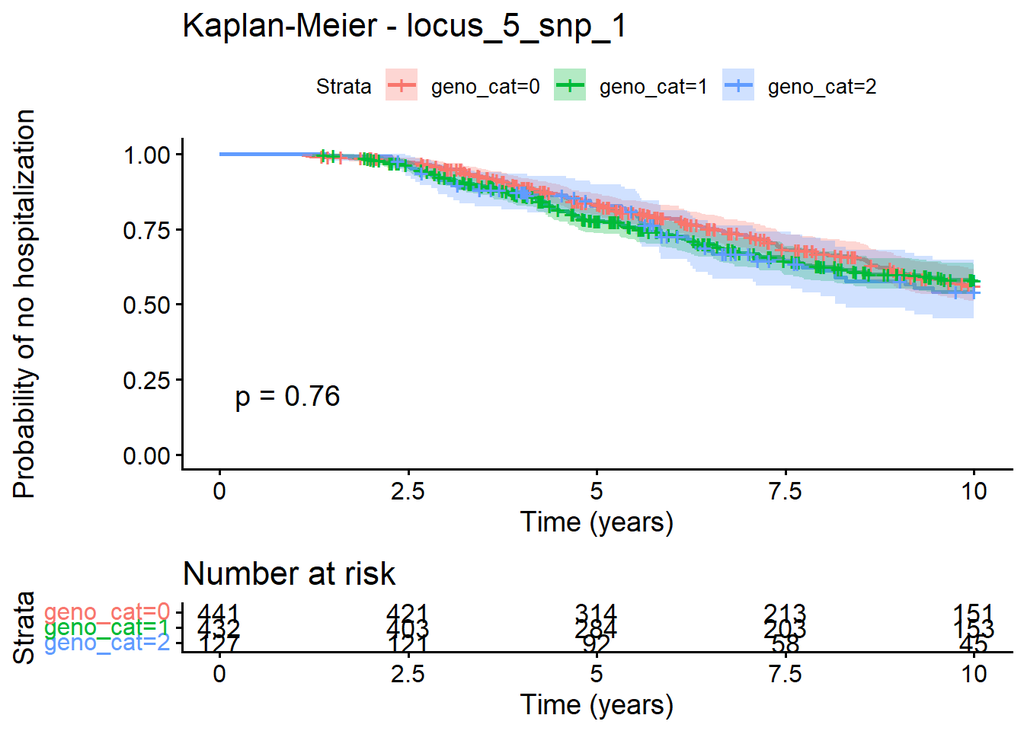

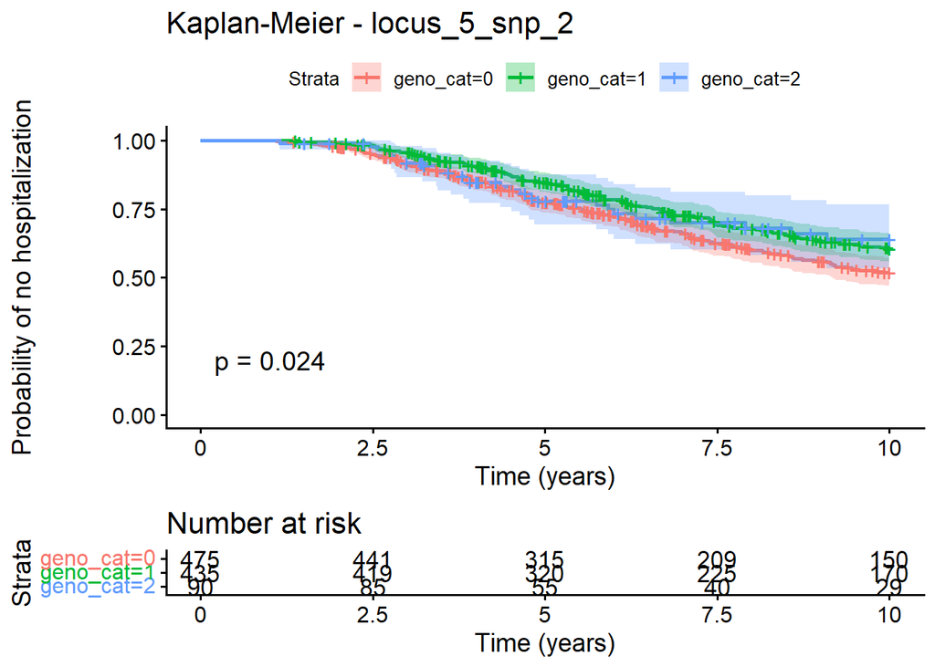

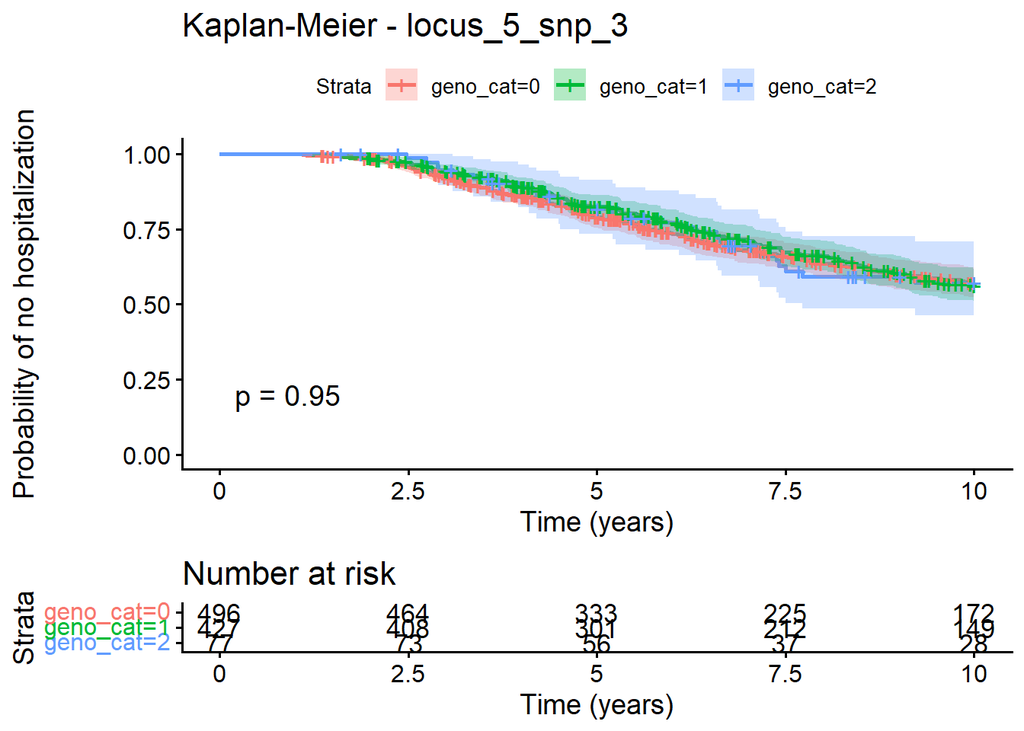

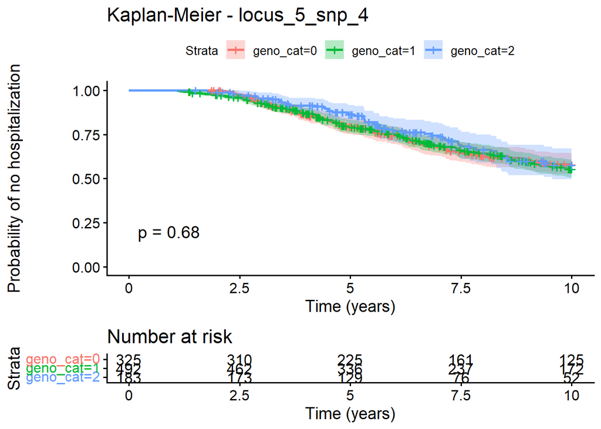

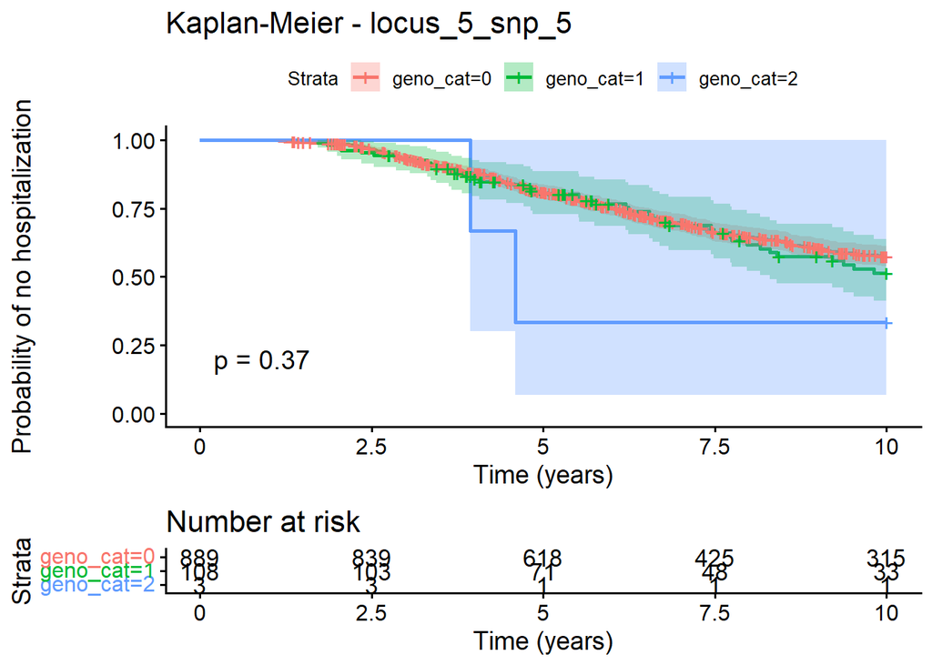

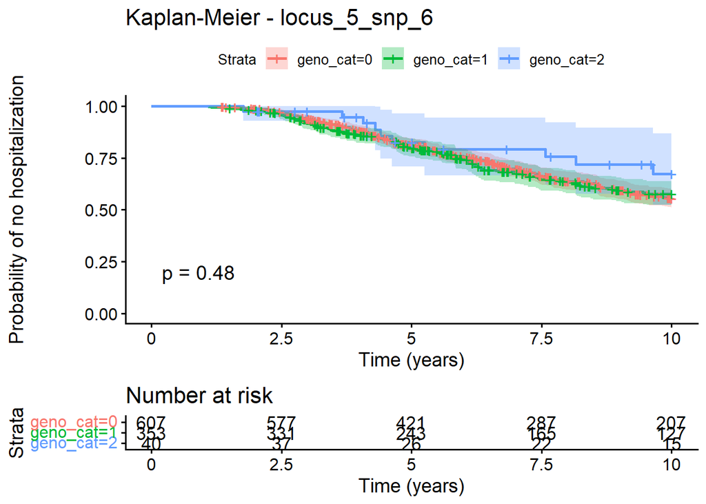

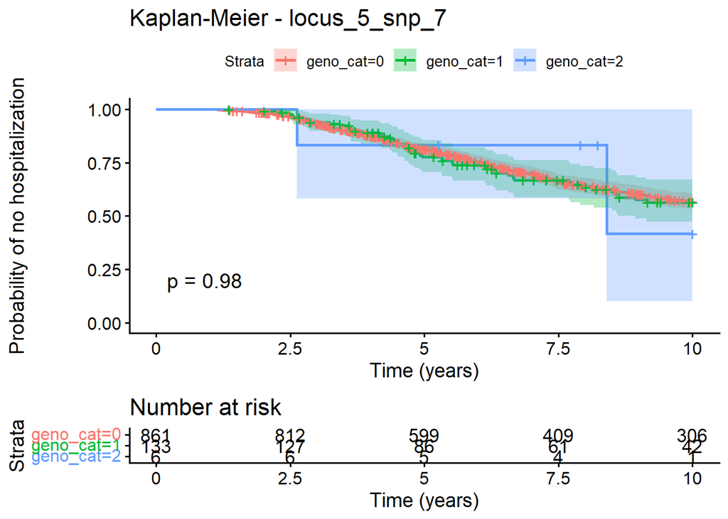

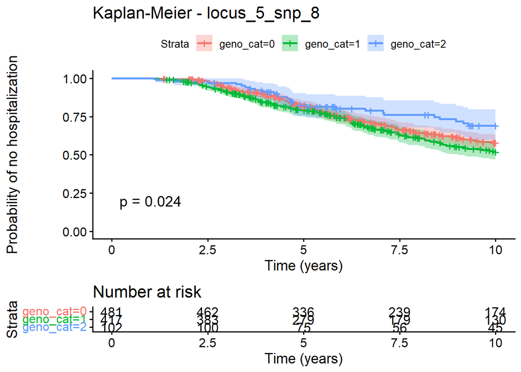

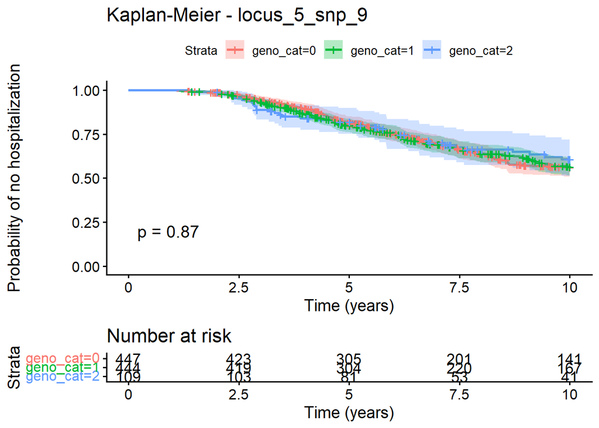

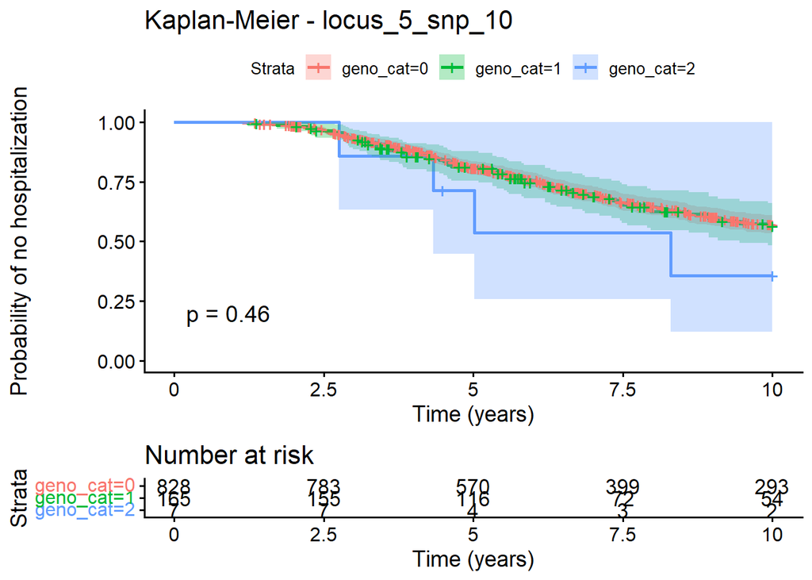

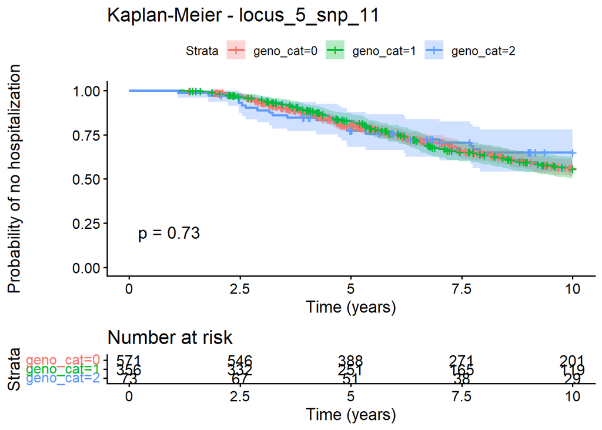

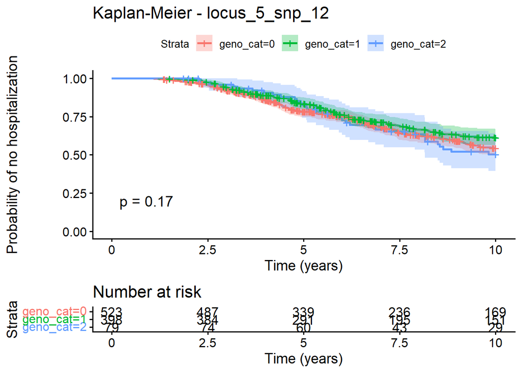

[29 more figures not shown]

```r
#Kaplan-Meier curves stratified by genotype for each locus_5 SNP
for (snp in snps_locus5) {

  # Remove rows with missing genotype for this SNP
  df_snp <- data_locus5[!is.na(data_locus5[[snp]]), ]

  # Create genotype factor dropping empty levels
  df_snp$geno_cat <- droplevels(df_snp[[snp]])

  # Skip SNP if fewer than 2 genotype groups are present
  if (nlevels(df_snp$geno_cat) < 2) next

  # Fit Kaplan-Meier curves stratified by genotype
  km_fit <- survfit(
    Surv(time_to_severe_outcome, status_hosp) ~ geno_cat,
    data = df_snp
  )

  # Plot KM curves
  km_plot <- ggsurvplot(
    km_fit,
    data = df_snp,
    conf.int = TRUE,
    risk.table = TRUE,
    pval = TRUE,
    title = paste("Kaplan-Meier -", snp),
    xlab = "Time (years)",
    ylab = "Probability of no hospitalization"
  )

  suppressMessages(print(km_plot))
}
```

### Interpretation

Kaplan-Meier curves were estimated for 41 SNPs in locus_5 (locus_5_snp_26 was excluded as all values were missing), stratified by genotype group (0, 1, 2). For most SNPs the three curves largely overlap, suggesting no strong systematic association between locus_5 variants and time to hospitalization. In some SNPs, carriers of two copies of the alternative allele (genotype 2) tend to show lower survival probability over time compared to genotypes 0 and 1, though confidence intervals are wide due to the small sample size in genotype group 2. Overall, genotype groups 0 and 1 show similar survival patterns across most SNPs, while genotype 2 occasionally shows more divergent trajectories.

From a biological perspective, the lack of consistent separation between genotype groups suggests that the variants in locus_5 do not appear to have a strong influence on the risk of hospitalization.

## Step 4

```r
p.values_unadj <- c()

#Log-rank test
for (snp in snps_locus5) {

  df_snp <- data_locus5[!is.na(data_locus5[[snp]]), ]
  df_snp$geno_cat <- droplevels(df_snp[[snp]])
  if (nlevels(df_snp$geno_cat) < 2) next

  log_rank_test <- survdiff(
    Surv(time_to_severe_outcome, status_hosp) ~ geno_cat,
    data = df_snp
  )
  p.values_unadj[snp] <- log_rank_test$pvalue

}

#No correction
decision_unadj <- rep("Do not reject H0", length(p.values_unadj))
decision_unadj[p.values_unadj <= 0.05] <- "Reject H0"

table(decision_unadj)
```

```
## decision_unadj
## Do not reject H0        Reject H0
##               35                6
```

```r
#FWER
FWER <- 1 - (1 - 0.05)^length(p.values_unadj)
FWER
```

```
## [1] 0.8779135
```

```r
#Bonferroni correction
p.values_BF <- p.adjust(p.values_unadj,method = "bonferroni")

decision_adj_BF <- rep("Do not reject H0",length(p.values_BF))
decision_adj_BF[p.values_BF<=0.05] <- "Reject H0"

table(decision_adj_BF)
```

```
## decision_adj_BF
## Do not reject H0
##               41
```

```r
#Holm correction
p.values_HM <- p.adjust(p.values_unadj,method = "holm")

decision_HM <- rep("Do not reject H0",length(p.values_HM))
decision_HM[p.values_HM<=0.05] <- "Reject H0"

table(decision_HM)
```

```
## decision_HM
## Do not reject H0
##               41
```

```r
#Benjamini-Hochberg correction
p.values_BH <- p.adjust(p.values_unadj,method = "BH")

decision_BH <- rep("Do not reject H0",length(p.values_BH))
decision_BH[p.values_BH<=0.05] <- "Reject H0"

table(decision_BH)
```

```
## decision_BH
## Do not reject H0
##               41
```

### Interpretation

The log-rank test was chosen as it is a non-parametric test that does not assume any particular distribution of survival times, and is the standard approach for comparing survival curves across groups. The log-rank test was applied to formally assess whether survival distributions differ across genotype groups for each SNP. Without correction for multiple testing, 6 out of 41 SNPs showed a nominally significant p-value (p < 0.05). However, given that 41 tests were performed simultaneously, some significant results are expected by chance alone (FWER = 88% without correction). After applying multiple testing corrections (Bonferroni, Holm, and Benjamini-Hochberg at α = 0.05), no SNP remained statistically significant. This suggests that the nominally significant results are likely false positives, and there is no robust statistical evidence of association between locus_5 variants and hospitalization.

From a biological perspective, these results suggest that the genetic variants in locus_5 do not appear to determine the risk of hospitalization in this patient population.

## Step 5

```r
#locus_5_snp_39 as representative SNP
df_locus_5_snp_39 <- data_locus5[!is.na(data_locus5[["locus_5_snp_39"]]), ]
df_locus_5_snp_39$geno_cat <- droplevels(df_locus_5_snp_39[["locus_5_snp_39"]])

#KM curves
km_fit_locus_5_snp_39 <- survfit(
  Surv(time_to_severe_outcome, status_hosp) ~ geno_cat,
  data = df_locus_5_snp_39
)

print(km_fit_locus_5_snp_39)
```

```
## Call: survfit(formula = Surv(time_to_severe_outcome, status_hosp) ~
##     geno_cat, data = df_locus_5_snp_39)
##
##              n events median 0.95LCL 0.95UCL
## geno_cat=0 689    266     NA      NA      NA
## geno_cat=1 284     79     NA      NA      NA
## geno_cat=2  27     12   8.22    5.52      NA
```

```r
print(summary(km_fit_locus_5_snp_39, times = c(2, 5, 10)))
```

```
## Call: survfit(formula = Surv(time_to_severe_outcome, status_hosp) ~
##     geno_cat, data = df_locus_5_snp_39)
##
##                 geno_cat=0
##  time n.risk n.event survival std.err lower 95% CI upper 95% CI
##     2    672      12    0.983 0.00499        0.973        0.992
##     5    473     122    0.795 0.01588        0.764        0.826
##    10    240     132    0.541 0.02141        0.500        0.584
##
##                 geno_cat=1
##  time n.risk n.event survival std.err lower 95% CI upper 95% CI
##     2    277       3    0.989 0.00611        0.977        1.000
##     5    201      36    0.847 0.02259        0.804        0.893
##    10    102      40    0.643 0.03321        0.581        0.712
##
##                 geno_cat=2
##  time n.risk n.event survival std.err lower 95% CI upper 95% CI
##     2     26       0    1.000  0.0000        1.000        1.000
##     5     16       7    0.724  0.0893        0.569        0.922
##    10      7       5    0.474  0.1089        0.302        0.744
```

### Interpretation

As the representative SNP, I selected locus_5_snp_39, which had the lowest unadjusted p-value (p = 0.0088). The median time to hospitalization was not reached in genotype groups 0 and 1, while in genotype group 2 it was 8.22 years (95% CI: 5.52 - NA). At 2 years survival probabilities were similar across groups (98.3%, 98.9%, 100% for genotypes 0, 1, 2 respectively). At 5 years, differences began to emerge (79.5%, 84.7%, 72.4% for genotypes 0, 1, 2 respectively). Differences became more pronounced at 10 years, where genotype 1 had the highest survival probability (64.3%), followed by genotype 0 (54.1%) and genotype 2 (47.4%). However, genotype group 2 contains only 27 patients, resulting in wide confidence intervals and unreliable estimates. These findings should be interpreted with caution given the lack of significance after multiple testing correction.

From a biological perspective, the suggestive pattern observed in locus_5_snp_39, where carriers of two copies of the alternative allele (genotype 2) show lower survival probability over time, could indicate a potential genetic susceptibility to severe outcomes. However, given the lack of statistical significance after multiple testing correction and the small sample size in genotype group 2, this finding cannot be considered conclusive.

## Final Comment for Question 2

The analysis of 41 SNPs in locus_5 found no statistically significant association between genetic variants and time to severe clinical outcome (hospitalization) after correction for multiple testing. While 6 SNPs showed nominal significance, these results did not survive any of the three correction methods applied (Bonferroni, Holm, BH), suggesting they likely represent false positives arising from multiple testing. The representative SNP locus_5_snp_39 showed a suggestive pattern at 10 years, with carriers of two copies of the minor allele having lower survival probability (47.4% vs 64.3% in heterozygotes), but the small sample size in genotype group 2 limits the reliability of this observation. Overall, locus_5 does not appear to harbor variants with a strong effect on time to hospitalization in this dataset.